# Chapter 4 Multivariate normal distributions

Normal distributions for more than 1 variable.

Review: Univariate normal distributions

A random variable follows a normal distribution if its probability density has the form

$$ f(x) = \frac{1}{\sigma \sqrt {2 \pi} } e^{-\frac{(x-\mu)^2}{2 \sigma^2}} $$

$\mu$: the mean

$\sigma $: the standard deviation.

Standard normal distribution is a normal distribution with a mean of 0 and a standard deviation of 1.

$Z$: A standard normal random variable.

Question: a) plot the probability density curve for a standard normal distribution.

```
      b) plot the probability density curve for a normal distribution with a mean of 3.2 and the standard deviation of 7.1.
```

Outliers: $3 \sigma$ criteria for outliers.

$99.7\%$ of data fall within 3 standard deviations of the mean for a normal distribution.

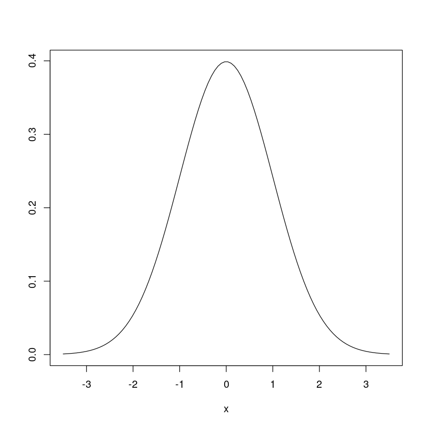

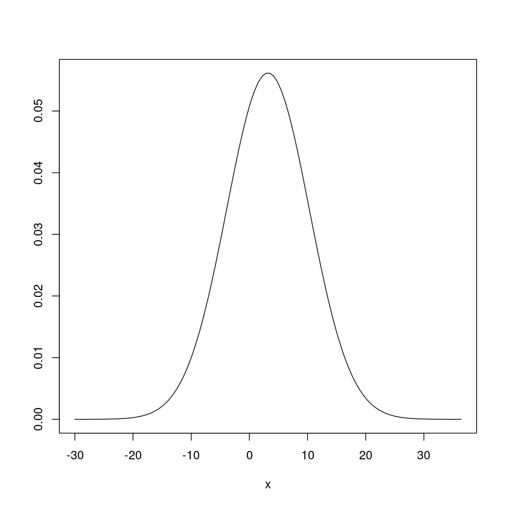

```r
#Normal probability curve for a standard normal

#The range to plot the curve

x = seq(-3.5, 3.5, length=100)

#the probability density on these values

y.pdf = dnorm(x, 0, 1)

plot(x, y.pdf, type ='l', ylab = "")

#b

#The range to be plotted
x = seq(-30, 36.4, length=100)

#the probability density on these values

y.pdf = dnorm(x, 3.2, 7.1)

plot(x, y.pdf, type ='l', ylab = "")
```

```r
#Plot the probability density a normal distribution

#Standard normal Z:  a normal distribution with a mean of zero and a standard deviation 1

x = seq( -4,  4,  by =0.1 )
#To calculate the normal probability density over x
#?dnorm
density= dnorm(x, mean = 0, sd = 1)
plot(x, density, type = "l")


#plot of a normal distribution with a mean of 10 and a standard deviation of 25

x = seq( -75,  95,  by =2 )
#To calculate the normal probability density over x
#?dnorm
density= dnorm(x, mean = 10, sd = 25)
plot(x, density, type = "l")
```

[output not shown]

# Normality check

If we would like to see if the data are from a normal distribution or not, we can run normlity check.

1. Histogram / boxplot
2. Normality tests
3. QQ normal plot

A QQ (Quantile-Quantile) normal plot is a graphical tool used to assess if a given dataset follows a normal distribution. It is a useful visual tool for checking assumptions about the distribution of data in data analysis. If the points in a QQ normal plot fall approximately along a line, it suggests that the data is normally distributed approximately. If the points deviate from the line, it indicates that the data may not follow a normal distribution.

# Example: check if the variable 'Total_length' of the Sparrow data is from a normal distribuiton or not approximately.

```r
# Use the sparrow data.
# Example: Find the mean, variance for varialbe "L_humerous" and construct a histgram for it

#Set the location of the file
lc = "~/Data1/Bumpus_sparrows.csv"

#header = 1  : the variable names are given in the first row of the .csv file
dat= read.csv(lc,  header = 1)

#To check if the data was loaded successfully or not , display the first few line or the last few lines
head(dat)
```

A data.frame: 6 × 6

|  | Survivorship <chr> | Total_length <int> | Alar_extent <int> | L_beak_head <dbl> | L_humerous <dbl> | L_keel_sternum <dbl> |
| --- | --- | --- | --- | --- | --- | --- |
| 1 | S | 156 | 245 | 31.6 | 18.5 | 20.5 |
| 2 | S | 154 | 240 | 30.4 | 17.9 | 19.6 |
| 3 | S | 153 | 240 | 31.0 | 18.4 | 20.6 |
| 4 | S | 153 | 236 | 30.9 | 17.7 | 20.2 |
| 5 | S | 155 | 243 | 31.5 | 18.6 | 20.3 |
| 6 | S | 163 | 247 | 32.0 | 19.0 | 20.9 |

49

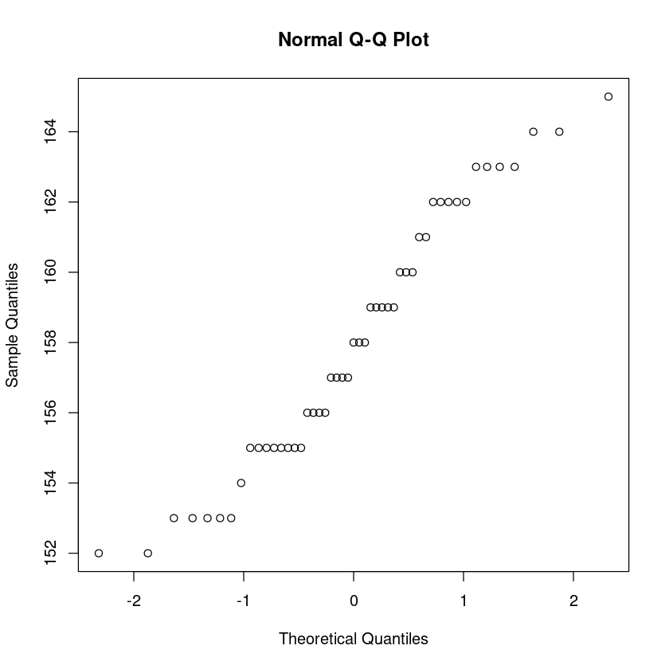

```r
#QQ normal plot
length(dat$Total_length)
qqnorm(dat$Total_length)

#The points on the qq normal plot roughly follow a straight line,
#It is reasonable to assume that the data are from a normal distribution approximately.
```

```r
#A few more qq normal plots
x = rnorm(8)
qqnorm(x)

#the sample size is small, a histogram /box plot may not be good.
```

[output not shown]

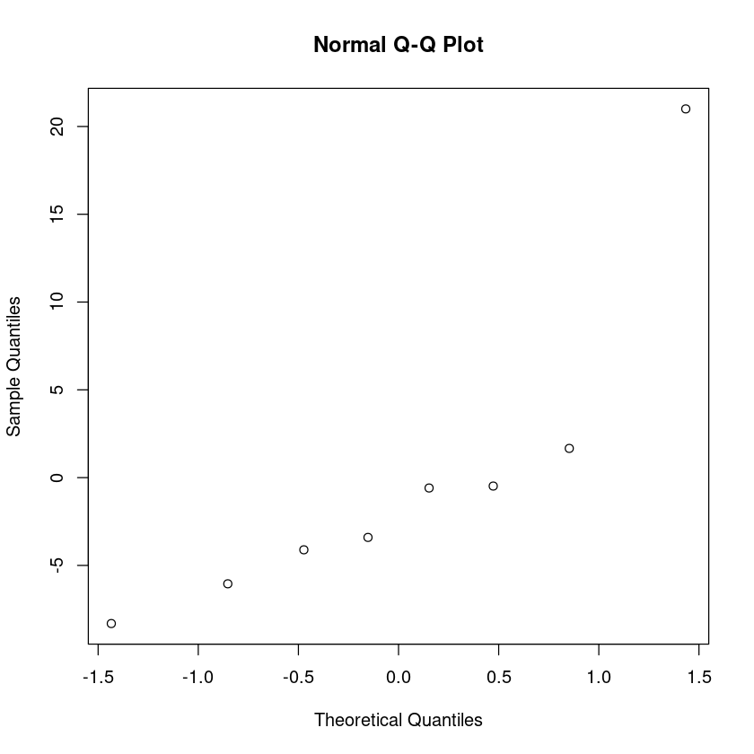

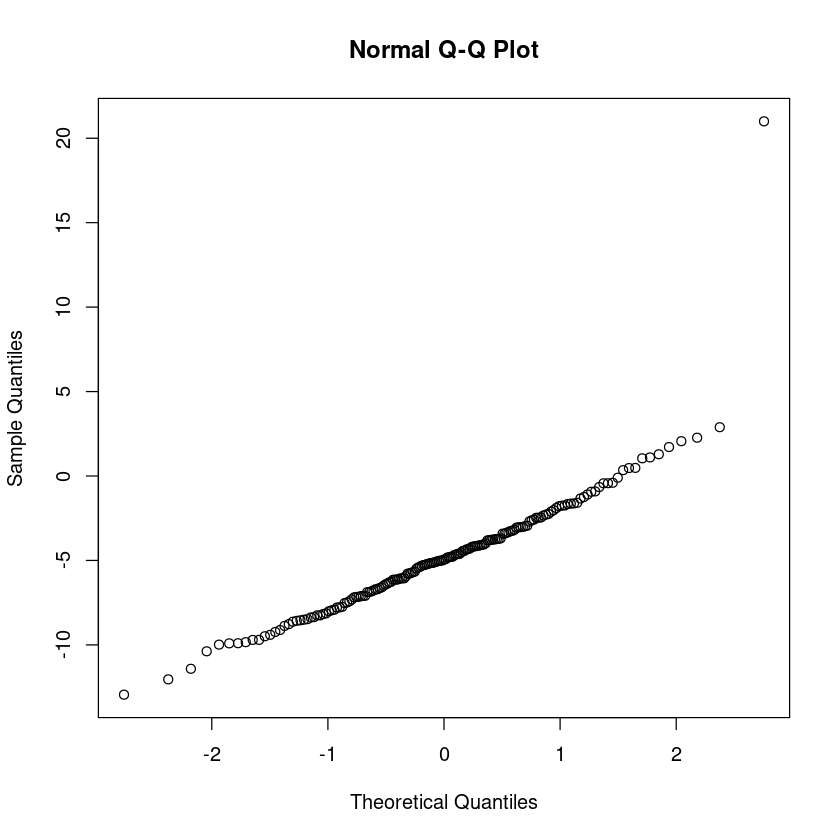

```r
#A non-normal case

x = rnorm( 7,  -5, 3)
x = c(x, 21)

#outlier : 21
qqnorm(x)

#The data are not from a normal distribution

x = rnorm( 170,  -5, 3)
x = c(x, 21)

#outlier : 21
qqnorm(x)

#The data are not from a normal distribution
```

Example: Construct qq normal plots for all variables

```r
#library(tidyverse)
#dat %>% gather()%>% ggplot(., aes(sample = value)) + stat_qq()+ facet_wrap(vars(key), scales ='free_y')
```

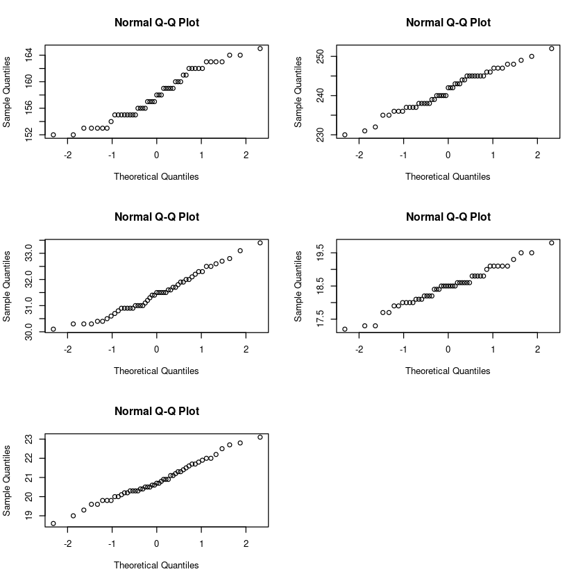

```r
#Make a few qq normal plots in one page
par(mfrow = c(3, 2)) # Create a 3 x 2 plotting matrix
for(i in 2:6)
{
    qqnorm( dat[,i])
}

#All variables seem from normal distributions.
```

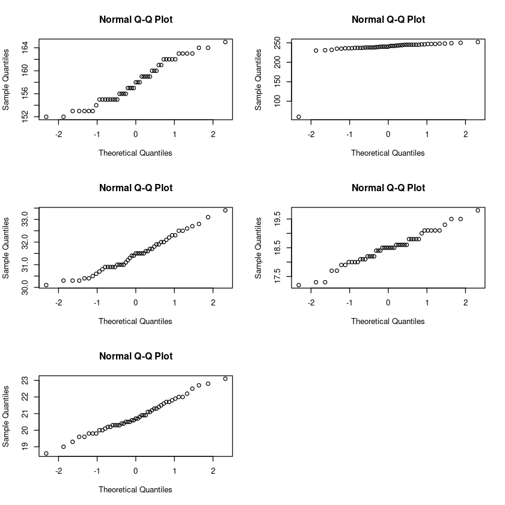

```r
#Make a few qq normal plots in one page
dat[5,3] = 60
par(mfrow = c(3, 2)) # Create a 3 x 2 plotting matrix
#for(i in c(2,5,6))
for(i in 2:6)
{
    qqnorm( dat[,i])
}
# the second variable is not from a normal distribution.
```

# Multivariate normal distributions

A multivariate normal distribution is the generalization of the univariate normal (bell curve) to multiple dimensions. Instead of describing a single random variable, it describes a vector of random variables that may be correlated with each other.

A $p$-dimensional random vector $\mathbf{X}$ has a multivariate normal distribution with a mean vector $\mathbf{\mu}$ and variance-covariance matrix $\Sigma$:

$$ \phi(\textbf{x})=\left(\frac{1}{2\pi}\right)^{p/2}|\Sigma|^{-1/2}\exp\{-\frac{1}{2}(\textbf{x}-\mathbf{\mu})'\Sigma^{-1}(\textbf{x}-\mathbf{\mu})\} $$$$ \mathbf{X} \sim N(\mathbf{\mu},\Sigma) $$

A bivariate normal: $$ \left(\begin{array}{c}X_1\\X_2 \end{array}\right) \sim N \left[\left(\begin{array}{c}\mu_1\\ \mu_2 \end{array}\right), \left(\begin{array}{cc}\sigma^2_1 & \rho \sigma_1\sigma_2 \\ \rho\sigma_1\sigma_2 & \sigma^2_2 \end{array}\right)\right] $$

### Key Properties

1. **Marginals**:  
   Any subset of components of $\mathbf{X}$ also follows a multivariate normal distribution.
2. **Linearity**:  
   Any linear combination $a^T \mathbf{X}$ is univariate normal.
3. **Independence & Zero Correlation**:  
   In a multivariate normal, uncorrelated variables are also independent (which is not true in general distributions).
4. **Geometry**:  
   Contours of equal probability density are ellipsoids, shaped by $\boldsymbol{\Sigma}$.

### Applications in Statistics and Machine Learning

The multivariate normal distribution is the foundation for much of multivariate statistics because:

- **Foundation for classical methods**  
  Many inferential procedures in multivariate statistics assume MVN:
  - **Hotelling’s $T^2$ test** (multivariate generalization of the $t$-test)
  - **MANOVA** (multivariate analysis of variance)
  - **Discriminant analysis**
  - **Factor analysis**
  - **Principal component analysis (PCA)** often assumes MVN to derive statistical properties.
- **Generative models**:  
  Gaussian Mixture Models (GMMs) use MVNs to model complex data distributions.

$$ p(\mathbf{x}) = \sum_{k=1}^K \pi_k \, \mathcal{N}(\mathbf{x} \mid \boldsymbol{\mu}_k, \boldsymbol{\Sigma}_k), $$

where

- $\pi_k$ = mixing coefficient for component $k$, with $\pi_k \geq 0$ and $\sum_{k=1}^K \pi_k = 1$,
- $\boldsymbol{\mu}_k$ = mean vector of the $k$-th Gaussian,
- $\boldsymbol{\Sigma}_k$ = covariance matrix of the $k$-th Gaussian,
- $\mathcal{N}(\mathbf{x} \mid \boldsymbol{\mu}_k, \boldsymbol{\Sigma}_k)$ = PDF of a multivariate normal distribution:

$$ \mathcal{N}(\mathbf{x} \mid \boldsymbol{\mu}, \boldsymbol{\Sigma}) = \frac{1}{(2\pi)^{d/2} |\boldsymbol{\Sigma}|^{1/2}} \exp \!\left( -\tfrac{1}{2} (\mathbf{x} - \boldsymbol{\mu})^T \boldsymbol{\Sigma}^{-1} (\mathbf{x} - \boldsymbol{\mu}) \right). $$

- **Classification**:  
  Linear/Quadratic Discriminant Analysis assume class-conditional MVNs.
- **Dimensionality reduction**:  
  Principal Component Analysis (PCA) relies on the covariance structure of an MVN.
- **Bayesian inference**:  
  Conjugate priors (normal-inverse-Wishart) simplify updates for Gaussian likelihoods.
- **Gaussian processes**:  
  Define distributions over functions using MVN properties.
- **Kalman filters**:  
  State-space models assume Gaussian noise for sequential prediction.

Example: Plot the probability density (pattern) of a bivariate normal with a mean vector of (2,6) and the covariance matrix

$$ C = \begin{bmatrix} 2 & -1 \\ -1 & 2 \end{bmatrix} $$

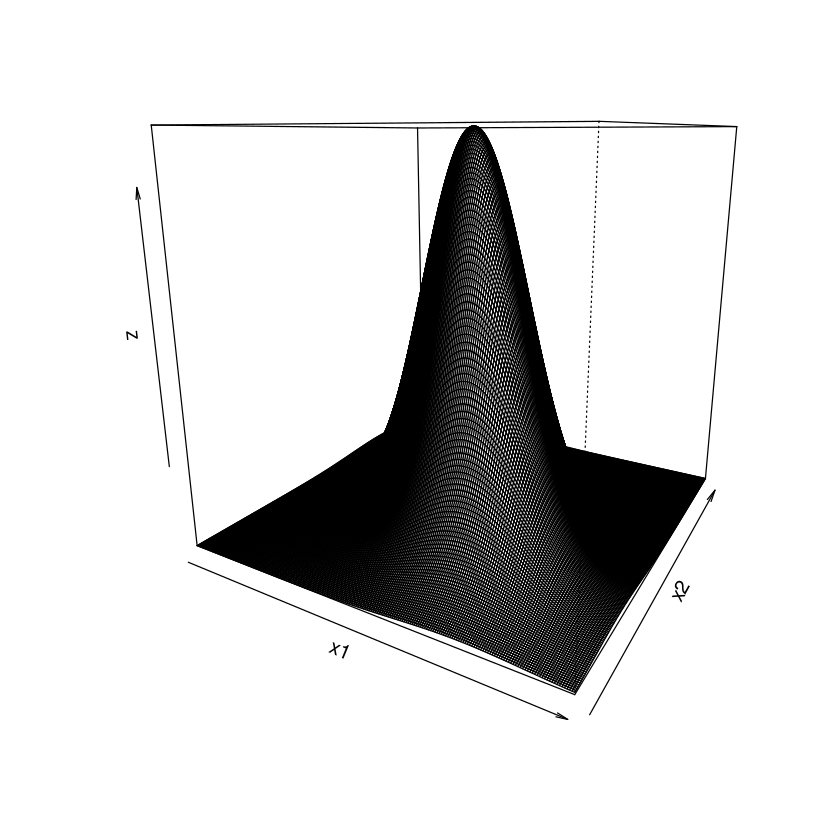

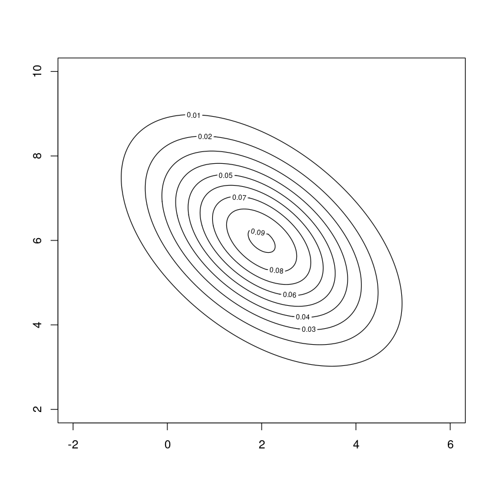

```r
library(mvtnorm)

mean.vec = c(2,6)
cmat = matrix( c(2,-1,-1,2), nrow = 2)

#Define a range of (x1, x2) for the plot

x1 = seq( -2, 6, length = 200  )
x2 = seq( 2, 10, length = 200  )

#multivariate normal probability density dmvnorm(cbind(x, y), mu, sigma0)

f = function(x, y) dmvnorm(cbind(x, y), mean.vec, cmat)
#calcualtion all points (x1, x2) in the grid
z = outer(x1, x2, f)
#A contour plot

#3d perspective plot
persp(x1, x2, z, theta = 30, phi = 15)

#Contour plot
#z : the value of the bivariate function over x1, x2
contour(x1, x2, z)
```

Example: Plot the probability density (pattern) of a bivariate normal with a mean vector of (2,6) and the covariance matrix

$$ C = \begin{bmatrix} 2 & 0 \\ 0 & 2 \end{bmatrix} $$

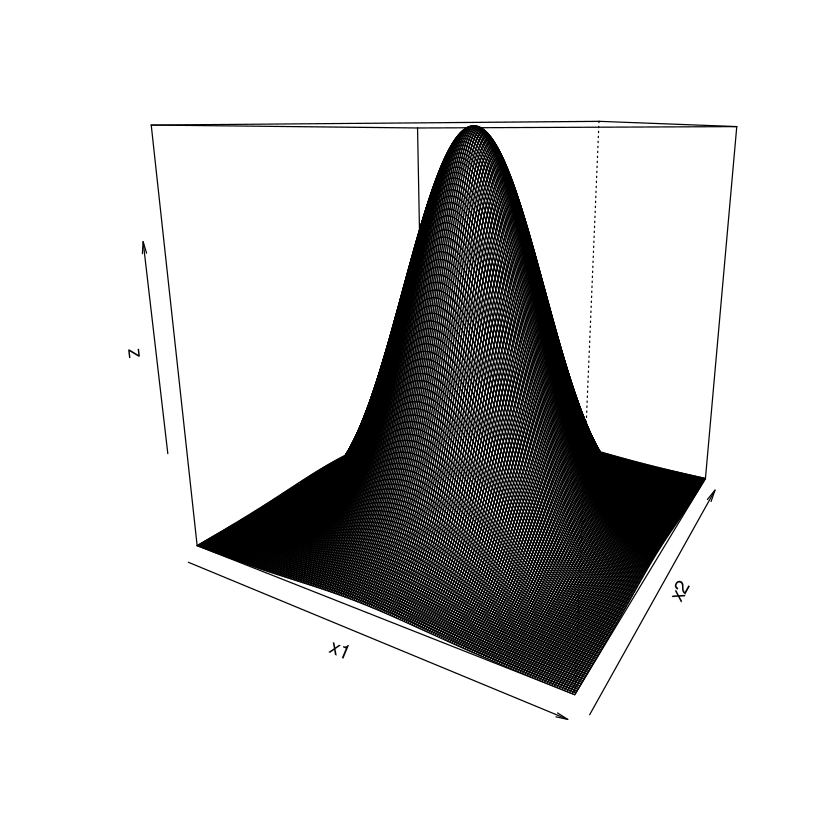

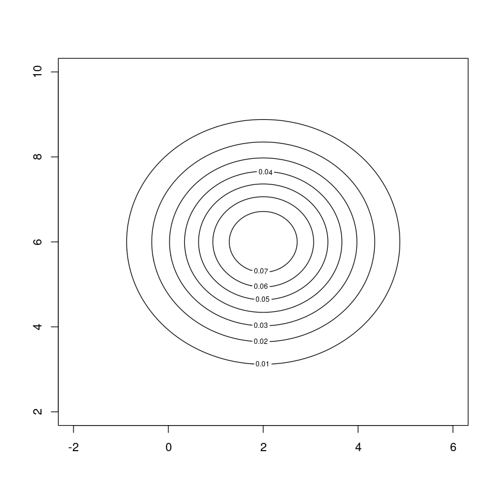

```r
#two variable are not correlated
library(mvtnorm)

mean.vec = c(2,6)
cmat = matrix( c(2,0,0,2), nrow = 2)

#Define a range of (x1, x2) for the plot

x1 = seq( -2, 6, length = 200  )
x2 = seq( 2, 10, length = 200  )

#multivariate normal probability density dmvnorm(cbind(x, y), mu, sigma0)

f = function(x, y) dmvnorm(cbind(x, y), mean.vec, cmat)
#calcualtion all points (x1, x2) in the grid
z = outer(x1, x2, f)
#A contour plot

#3d perspective plot
persp(x1, x2, z, theta = 30, phi = 15)

#Contour plot
#z : the value of the bivariate function over x1, x2
contour(x1, x2, z)
```

# Density plots for bivariate data

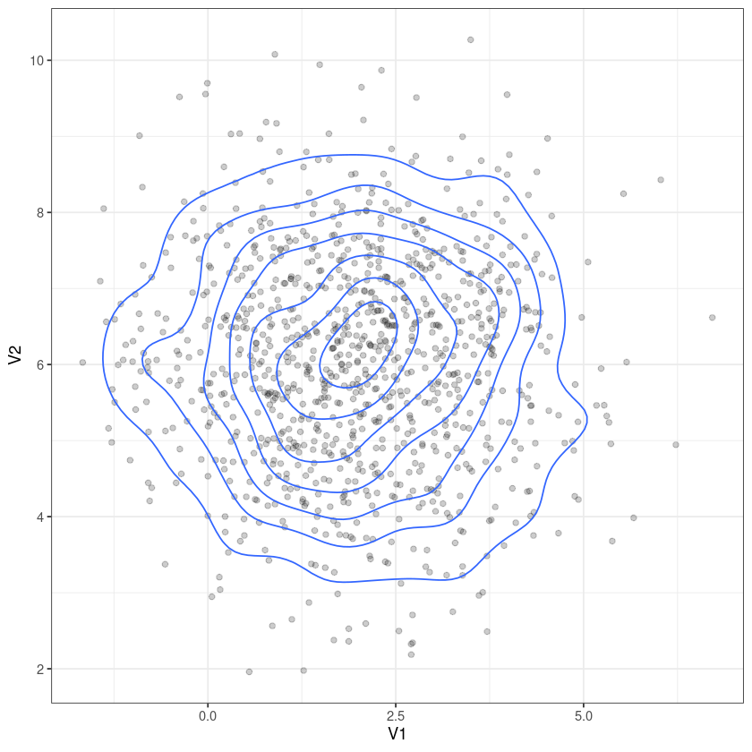

```r
#simulate 1000 observations
library(MASS)

mu = c(2, 6)
sigma0 = matrix(c(2, 0, 0, 2), nrow=2)

Mdat = mvrnorm(n = 1000, mu,sigma0)
M.dat = as.data.frame(Mdat)
ggplot(M.dat, aes(x=V1, y=V2))+ geom_point(alpha = .2) +  geom_density_2d()+  theme_bw()
```

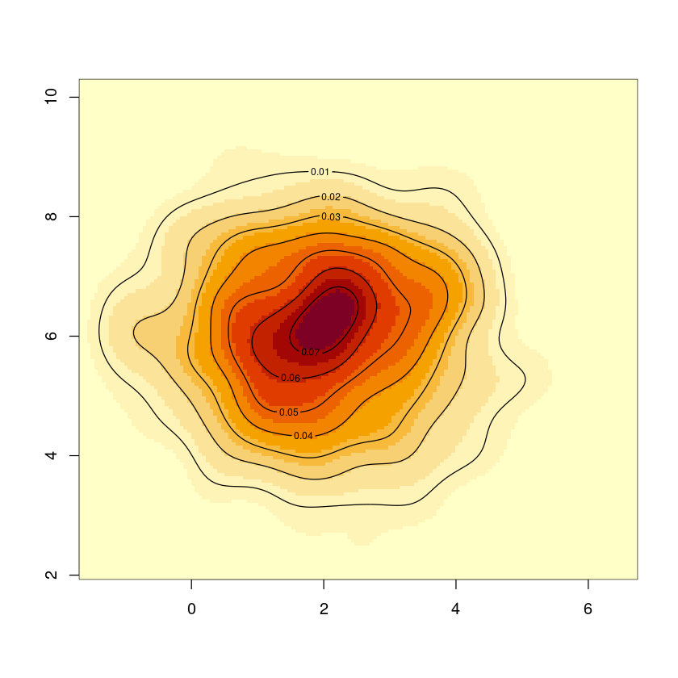

```r
#Bivariate probabality density estimation and plot
b.kde = kde2d(Mdat[,1], Mdat[,2], n = 150)
image(b.kde)
contour(b.kde, add = TRUE)
```

Use the **sparrow dataset**.

**a.** Using kernel density estimation, construct 2 dimensional density plots for the variables

- `Alar_extent`
- `L_beak_head`

**b.** Assume that the pair `Alar_extent`,`L_beak_head` follows a bivariate normal distribution. Use the **sample mean vector** as $\mu$ and the **sample covariance matrix** as $\Sigma$. Plot the fitted bivariate normal distribution (e.g., with contour lines and/or a 3D surface).

```r
#Set the location of the file
lc = "Bumpus_sparrows.csv"

#header = 1  : the variable names are given in the first row of the .csv file
dat= read.csv(lc,  header = 1)

#To check if the data was loaded successfully or not , display the first few line or the last few lines
head(dat)
```

A data.frame: 6 × 6

|  | Survivorship <chr> | Total_length <int> | Alar_extent <int> | L_beak_head <dbl> | L_humerous <dbl> | L_keel_sternum <dbl> |
| --- | --- | --- | --- | --- | --- | --- |
| 1 | S | 156 | 245 | 31.6 | 18.5 | 20.5 |
| 2 | S | 154 | 240 | 30.4 | 17.9 | 19.6 |
| 3 | S | 153 | 240 | 31.0 | 18.4 | 20.6 |
| 4 | S | 153 | 236 | 30.9 | 17.7 | 20.2 |
| 5 | S | 155 | 243 | 31.5 | 18.6 | 20.3 |
| 6 | S | 163 | 247 | 32.0 | 19.0 | 20.9 |

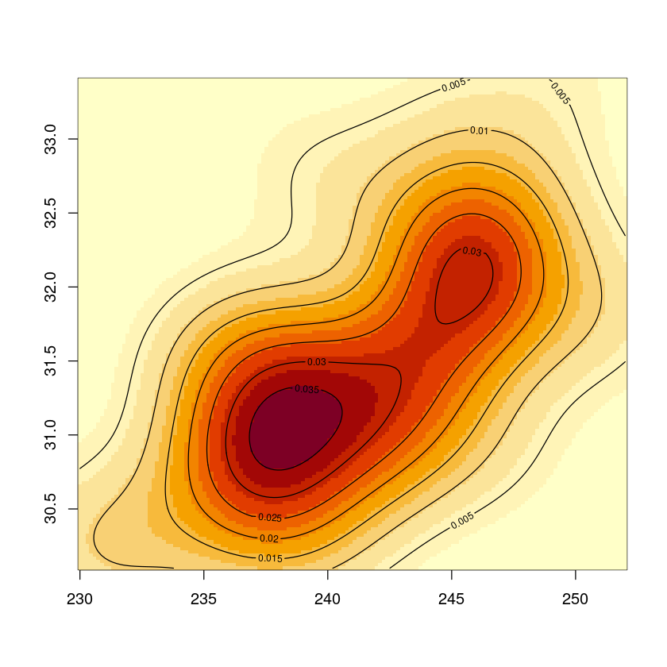

```r
#a. Please construct a density plot for the variables 'Alar_extent' and 'L_beak_head' using the kernel estimate.

b.kde = kde2d(dat[,3], dat[,4], n = 150)
image(b.kde)
contour(b.kde, add = TRUE)

#may be the data are not from a bivariate normal,  because it shows bimodal
```

```r
#b. If we assume that the variables 'Alar_extent' and 'L_beak_head' have a bivariate normal distribution.
# Plot the the bivariate normal distribution with the mean = the sample mean, the covariance matrix = the sample covariance matrix.

sm.vec = c(mean(dat$Alar_extent) , mean(dat$L_beak_head))
cov.mat = cov(dat[, 3:4])
sm.vec

cov.mat
```

1. 241.326530612245

2. 31.4591836734694

A matrix: 2 × 2 of type dbl

|  | Alar_extent | L_beak_head |
| --- | --- | --- |
| Alar_extent | 25.682823 | 2.7136054 |
| L_beak_head | 2.713605 | 0.6316327 |

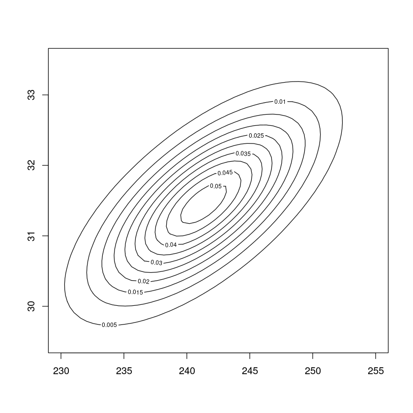

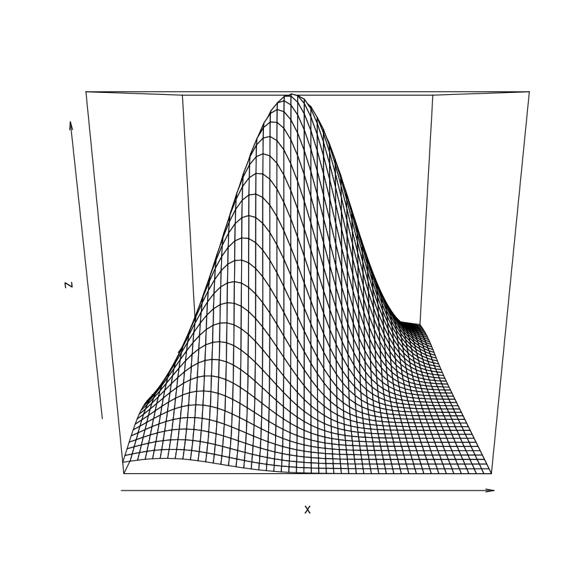

```r
#where to plot the pattern
x = seq(230  , 255 , length = 50)
y = seq(29.5, 33.5, length = 50)

#specified by mean and the covariance matrix sigma.
mu = sm.vec
sigma0 = cov.mat

#dmvnorm computes the density function of the multivariate normal
#dmvnorm(x, mean = mu, sigma = sigma0, log = FALSE, checkSymmetry = TRUE)

f = function(x, y) dmvnorm(cbind(x, y), mu, sigma0)
z = outer(x, y, f)
#A contour plot
contour(x, y, z)
#3d perspective plot
persp(x, y, z)
```

```r
#To make a probablity density plot for Total_length and Alar_extent


#Bivariate probabality density estimation and plot
b.kde = kde2d(dat[,2], dat[,3], n = 500)
image(b.kde)
contour(b.kde, add = TRUE)

#the plot of the probability density is not very reliable when the sample size is not large engough.
```

[output not shown]

# Confidence Intervals/Regions

A confidence interval for a population parameter is a range (region) to caputure the unknown population parameter with a certain level of confidence.

For example : a 90% confidence interval for the population mean of variable " Alar_extent", that is, we are 90% sure that the population mean of variable " Alar_extent" is in the interval. A confidence interval is an interval in the number line.

A 95% confidence region for the population mean vector of "Total_length " and "Alar_extent": we are 95% confidence that the the population mean vector of "Total_length " and "Alar_extent" fall in the region.

A confidence region is a multi-dimensional generalization of a confidence interval.

$$(\mathbf{x}-\boldsymbol\mu)^T\boldsymbol\Sigma^{-1}(\mathbf{x}-\boldsymbol\mu)\le \chi_{p,\alpha}^2 \tag{1}$$

Example: Construct a 95% confidence interval for the population mean of Alar_extent. Please interpret it.

```r
#Load the data

head(dat)

#For a population mean:  one sample t confidence interval
#if the sample size is not too small
#or the data are from a nomral distribution approximately.

with(data=dat, t.test(Alar_extent, conf.level=0.95))

#We are 95% sure that the population mean of Alar_extent is between 239.87, and 242.78.
```

A data.frame: 6 × 6

|  | Survivorship <chr> | Total_length <int> | Alar_extent <int> | L_beak_head <dbl> | L_humerous <dbl> | L_keel_sternum <dbl> |
| --- | --- | --- | --- | --- | --- | --- |
| 1 | S | 156 | 245 | 31.6 | 18.5 | 20.5 |
| 2 | S | 154 | 240 | 30.4 | 17.9 | 19.6 |
| 3 | S | 153 | 240 | 31.0 | 18.4 | 20.6 |
| 4 | S | 153 | 236 | 30.9 | 17.7 | 20.2 |
| 5 | S | 155 | 243 | 31.5 | 18.6 | 20.3 |
| 6 | S | 163 | 247 | 32.0 | 19.0 | 20.9 |

```
	One Sample t-test

data:  Alar_extent
t = 333.34, df = 48, p-value < 2.2e-16
alternative hypothesis: true mean is not equal to 0
95 percent confidence interval:
 239.8709 242.7822
sample estimates:
mean of x
 241.3265
```

Example: how many observations of bivariate data ("Total_length " and "Alar_extent") are out of the 99% prediction ellipse if the data are from a bivariate normal with the mean = the sample mean , and the covariance matrix = the sample covariance matrix. Prediction ellipse is for a new observation.

```r
#To find the mean vector
dat.23 = dat[,2:3]

#Find the mean vector
mean.vec = colMeans(dat.23)
mean.vec

#Find the sample covariance
cov.mat23 = cov(dat.23)
cov.mat23
```

**Total_length**

157.979591836735

**Alar_extent**

241.326530612245

A matrix: 2 × 2 of type dbl

|  | Total_length | Alar_extent |
| --- | --- | --- |
| Total_length | 13.35374 | 13.61097 |
| Alar_extent | 13.61097 | 25.68282 |

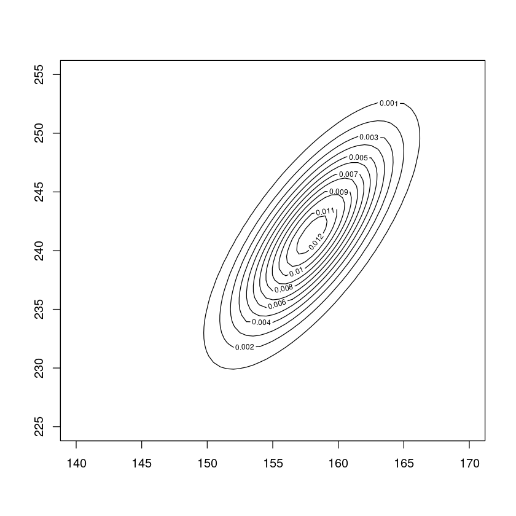

```r
library(mvtnorm)
#A bivariate normal distribution
x = seq(140, 170, 0.5)
y = seq(225, 255, 0.5)

#specified by mean and the covariance matrix sigma.
mu = mean.vec
sigma0 = cov.mat23


#dmvnorm computes the density function of the multivariate normal
#dmvnorm(x, mean = mu, sigma = sigma0, log = FALSE, checkSymmetry = TRUE)

f = function(x, y) dmvnorm(cbind(x, y), mu, sigma0)
z = outer(x, y, f)
#A contour plot for the bivariate normal distribution
contour(x, y, z)
```

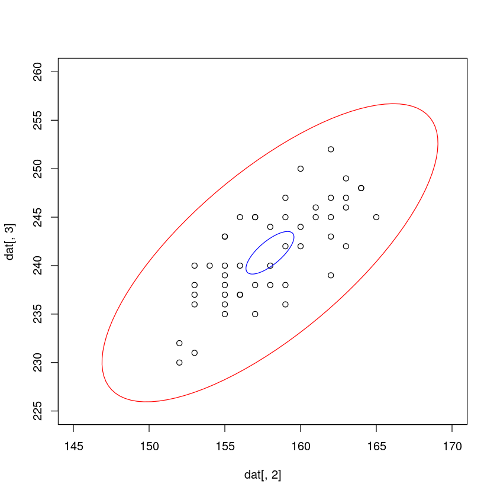

```r
library(ellipse)
#99% Prediction region
plot(dat[,2], dat[,3], xlim=c(145, 170), ylim=c(225,260))
lines(ellipse(x=sigma0, center=mu, level = 0.99 ), col="red")       # ellipse() from ellipse package

#99% Confidence region
n.size = length(dat[,2])
lines(ellipse(x=sigma0/n.size, center=mu, level = 0.99 ), col="blue")       # ellipse() from ellipse package
```

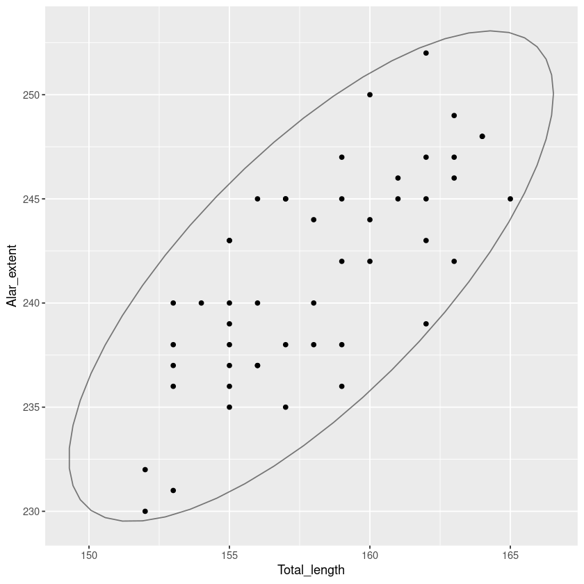

```r
#Make a plot for the prediction region
library(ggplot2)
ggplot(dat[,c(2,3)], aes(x = Total_length, y = Alar_extent)) +  geom_point() +  stat_ellipse(alpha = 0.5)
```

# Normality check for multivariate data

To check if several variables follow a multivariate normal distribution or not.

Multivariate QQ normal plot instead of using a univariate QQ normal plot multiple times. That each of all individual variables has a normal distribution does not imply multivariate normal of all these variables.

# Example: construct a multivariate QQ normal plot to check if all quantative variables in the data are from a joint multivariate normal distribution.

Since all the points in the QQ normal plot roughly follow a straight line pattern, the data (the quantitatvie varaibles of the sparrow data) are form a multivariate normal approximately.

For high dimensional data , p (the number of variables) is not small (even large) compared to the sample size (n), we may be careful.

```
Call: mardia(x = dat[, 2:6])

Mardia tests of multivariate skew and kurtosis
Use describe(x) the to get univariate tests
n.obs = 49   num.vars =  5
b1p =  4.83   skew =  39.46  with probability  <=  0.28
 small sample skew =  42.73  with probability <=  0.17
b2p =  34.48   kurtosis =  -0.22  with probability <=  0.83
```

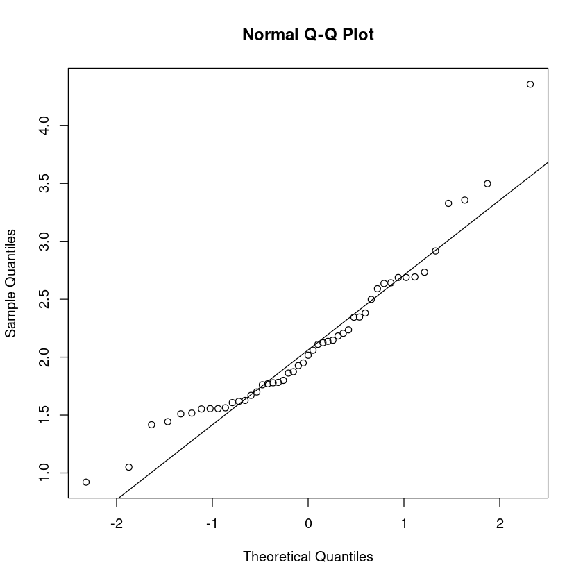

```r
#Multivariate QQ normal plot
library(psych)
mardia(dat[,2:6])
```

## Linear Transformation of a Multivariate Normal

Temperature data (x) in Celsis to Fairenheit: y = 9/5 x + 32

Let a $p$-dimensional random vector be

$$ \mathbf{X}_i = \begin{pmatrix} X_{i1} \\ X_{i2} \\ \vdots \\ X_{ip} \end{pmatrix}. $$

A **linear combination** of the components is

$$ Y = c_1 X_1 + c_2 X_2 + \dots + c_p X_p = \sum_{j=1}^p c_j X_j = \mathbf{c}^T \mathbf{X}, $$

where $\mathbf{c} = (c_1, c_2, \dots, c_p)^T$ is a vector of constants.  
More generally, a **linear transformation** is given by

$$ A \mathbf{X}_i, $$

where $A$ is a $k \times p$ matrix.

### 1. Mean of a Linear Combination

The expectation of $Y = \mathbf{c}^T \mathbf{X}$ is

$$ E(Y) = \sum_{j=1}^p c_j E(X_j) = \mathbf{c}^T \mu, $$

where $\mu = E(\mathbf{X})$ is the mean vector of $\mathbf{X}$.

Thus, the mean of a linear combination is simply the linear combination of the individual means.

### 2. Variance of a Linear Combination

The variance of $Y$ is

$$ \begin{aligned} Var(Y) &= Var\!\left(\sum_{j=1}^p c_j X_j \right) \\[6pt] &= Cov\!\left(\sum_{i=1}^p c_i X_i,\; \sum_{j=1}^p c_j X_j \right) \\[6pt] &= \sum_{i=1}^p \sum_{j=1}^p c_i c_j \, Cov(X_i, X_j) \\[6pt] &= \mathbf{c}^T \Sigma \mathbf{c}, \end{aligned} $$

where $\Sigma = Cov(\mathbf{X})$ is the covariance matrix.

### 3. Extension: Linear Transformation with a Matrix

For a general matrix $A$ and random vector $\mathbf{X}$, define

$$ \mathbf{Y} = A \mathbf{X}. $$

- The **mean vector** of $\mathbf{Y}$ is
  $$ E(\mathbf{Y}) = A \, E(\mathbf{X}) = A \mu. $$
- The **covariance matrix** of $\mathbf{Y}$ is
  $$ Cov(\mathbf{Y}) = A \, \Sigma \, A^T. $$

### Summary

- Linear combinations of multivariate normal random vectors are also normal.
- The mean and variance follow from the properties of expectation and covariance:
  - $E(\mathbf{c}^T \mathbf{X}) = \mathbf{c}^T \mu$
  - $Var(\mathbf{c}^T \mathbf{X}) = \mathbf{c}^T \Sigma \mathbf{c}$
- For a general transformation $A \mathbf{X}$:
  - $E(A \mathbf{X}) = A \mu$
  - $Cov(A \mathbf{X}) = A \Sigma A^T$

Example: Suppose that we are interested in the difference between the 0-day and the 4-day measurements. What is the distribution? Please plot the distribution.

Suppose that

- $X_1$: 0-day measurement
- $X_2$: 2-day measurement
- $X_3$: 4-day measurement

and $\mathbf{X} = (X_1, X_2, X_3)^{T}$ follows a multivariate normal distribution as $$ \mathbf{X} = (X_1, X_2, X_3)^\top \sim \mathcal N_3(\boldsymbol\mu, \Sigma), $$

with the mean vector

$$ \boldsymbol\mu = \begin{pmatrix} 259.5 \\ 230.8 \\ 221.5 \end{pmatrix}, \qquad \Sigma = \begin{pmatrix} 2276 & 1508 & 813 \\ 1508 & 2206 & 1349 \\ 813 & 1349 & 1865 \end{pmatrix}. $$

We are interested in the difference between Day-4 and Day-0:

$$ Y = X_3 - X_1 = - X_1 + 0 X_2 + X_3 = \mathbf{c}^\top \mathbf{X}, \quad \text{where } \mathbf{c} = (-1, 0, 1)^\top. $$

What is the mean of this difference $Y$? What is the standard deviation of $Y$?

Solution: The mean (expected) difference

The mean of Y = the mean of X3 - the mean of X1 = -1 x the mean of X1 + 0 x the mean of X2 + 1 x the mean of X3 = -38.

or $ E Y $ = the mean of the difference $ = \sum_{j=1}^{p}c_j E(X_j) $ $ = -1 \times E(X_1) + 0 \times E(X_2) + 1 \times E(X_3) = -1 \times 259.5 + 0 \times 230.8 + 1 \times 221.5 $  
$ = 221.5 - 259.5$ , which is $ E(X_3) - E(X_1) $ = -38.

$Var (Y) = Var(- X_1 + 0 X_2 + X_3 )$ , The varince = $\mathbf{c}^T \Sigma \mathbf{c}$

The problem can be solved using the code below:

```r
#To find the mean of a linear combination of multivariate vector
mean.v = c(259.5, 230.8, 221.5)
mean.y = t(c.vec) %*% mean.v
mean.y
```

A matrix: 1 × 1 of type dbl

| -38 |
| --- |

```r
#Find the variance a linear combination of multivariate vector

c.vec= c(-1, 0, 1)

cov.matrix = matrix( c(2276, 1508, 813,1508, 2206, 1349,813, 1349, 1865), nrow=3, byrow=1)

var.Y = t(c.vec)%*%cov.matrix%*%c.vec

var.Y

standard.dev.Y = sqrt(var.Y)

standard.dev.Y
```

A matrix: 1 × 1 of type dbl

| 2515 |
| --- |

A matrix: 1 × 1 of type dbl

| 50.14978 |
| --- |